# Comparing Supervised Learning Method

Young Seok Seo

4/15/2021

Compare the predictabilitty of Random Forest, Support Vector Machine, and NeuralNet methods using Banknote data

The banknote dataset involves predicting whether a given banknote is authentic given a number of measures taken from a photograph.

The dataset contains 1,372 rows with 5 numeric variables. It is a classification problem with two classes (binary classification).

Below provides a list of the five variables in the dataset.

variance of Wavelet Transformed image (continuous). skewness of Wavelet Transformed image (continuous). kurtosis of Wavelet Transformed image (continuous). entropy of image (continuous). class (integer).

## Packages

```r
library(tidyverse)
library(caret)
library(randomForest)
library(e1071)
library(neuralnet)
library(caTools)
```

## Read the ‘banknote’ data

```r
#Read the data
data <- read.csv('banknote.csv')
#Check number of missing values
colSums(is.na(data))
```

```
## variance skewness curtosis  entropy    class
##        0        0        0        0        0
```

```r
#Convert to factor
data$class <- as.factor(data$class)
```

## Data Parition

```r
set.seed(123)
training.samples <- data$class %>%
  createDataPartition(p = 0.75, list = FALSE)
train  <- data[training.samples, ]
test <- data[-training.samples, ]
```

```r
str(test)
```

```
## 'data.frame':    342 obs. of  5 variables:
##  $ variance: num  3.62 3.59 1.9 -1.58 3.4 ...
##  $ skewness: num  8.67 3.01 7.66 10.84 8.73 ...
##  $ curtosis: num  -2.807 0.729 0.154 2.546 -2.991 ...
##  $ entropy : num  -0.447 0.564 -3.111 -2.936 -0.572 ...
##  $ class   : Factor w/ 2 levels "0","1": 2 2 2 2 2 2 2 2 2 2 ...
```

## Random Forest

```r
fit <- randomForest(class ~ ., data = train, importance = TRUE)
fit
```

```
##
## Call:
##  randomForest(formula = class ~ ., data = train, importance = TRUE)
##                Type of random forest: classification
##                      Number of trees: 500
## No. of variables tried at each split: 2
##
##         OOB estimate of  error rate: 0.68%
## Confusion matrix:
##     0   1 class.error
## 0 456   2 0.004366812
## 1   5 567 0.008741259
```

```r
#Sensitivity = (predicted == 1 | class==1)
#Row = Real  /Col = Predicted
567 / (5 + 567)
```

```
## [1] 0.9912587
```

```r
#specificity = (predicted ==0|class == 0)
456 / (456 +2)
```

```
## [1] 0.9956332
```

```r
#accuracy
(567+456)/(456+2+5+567)
```

```
## [1] 0.9932039
```

```r
prediction <- fit %>% predict(test)
confusionMatrix(prediction,test$class, positive = "1")
```

```
## Confusion Matrix and Statistics
##
##           Reference
## Prediction   0   1
##          0 148   1
##          1   4 189
##
##                Accuracy : 0.9854
##                  95% CI : (0.9662, 0.9952)
##     No Information Rate : 0.5556
##     P-Value [Acc > NIR] : <2e-16
##
##                   Kappa : 0.9703
##
##  Mcnemar's Test P-Value : 0.3711
##
##             Sensitivity : 0.9947
##             Specificity : 0.9737
##          Pos Pred Value : 0.9793
##          Neg Pred Value : 0.9933
##              Prevalence : 0.5556
##          Detection Rate : 0.5526
##    Detection Prevalence : 0.5643
##       Balanced Accuracy : 0.9842
##
##        'Positive' Class : 1
##
```

```r
#As is, we have defined positive = 1
```

```r
#RandomForest
#Accuracy : 0.9932039
#Sensitivity : 0.9912587
#Specificity : 0.9956332
```

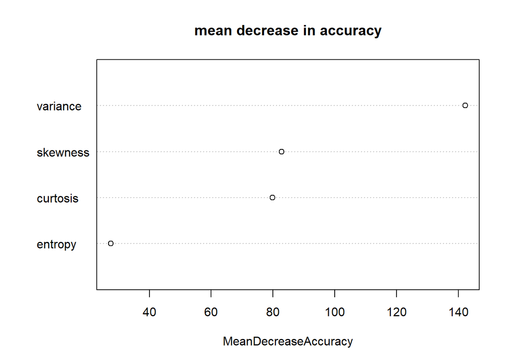

```r
#mean decrease in accuracy
#how each variable are important in this model
#higher value --> more important
varImpPlot(fit, type = 1, main = "mean decrease in accuracy")
```

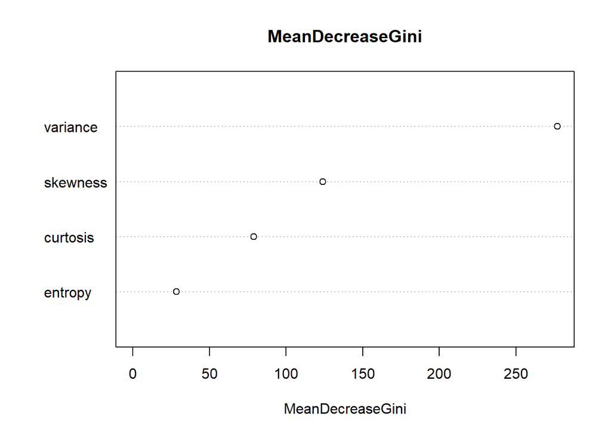

```r
#mean decrease in node impurity
varImpPlot(fit, type = 2, main = "MeanDecreaseGini")
```

```r
#MeanDecreaseAccuracy
importance(fit, type = 1)
```

```
##          MeanDecreaseAccuracy
## variance            142.12543
## skewness             82.77901
## curtosis             79.87335
## entropy              27.58992
```

## Support Vector Machine - Linear Kernel (C=1)

```r
#Support Vector Machine
# 1) Support Vector Machine using Linear Kernel with C = 1
# Mean 0, sd = 1
# Maximal Margin classifier  --> Margin : distance between the line and the nearset point of the both group. --> should be higher
set.seed(123)
model <- train(
  class ~., data = train, method = "svmLinear",
  trControl = trainControl("cv", number = 10),
  preProcess = c("center","scale")
  )
model
```

```
## Support Vector Machines with Linear Kernel
##
## 1030 samples
##    4 predictor
##    2 classes: '0', '1'
##
## Pre-processing: centered (4), scaled (4)
## Resampling: Cross-Validated (10 fold)
## Summary of sample sizes: 927, 927, 927, 927, 927, 927, ...
## Resampling results:
##
##   Accuracy   Kappa
##   0.9864167  0.9725997
##
## Tuning parameter 'C' was held constant at a value of 1
```

```r
# Make predictions on the test data
predicted.classes <- model %>% predict(test)
head(predicted.classes)
```

```
## [1] 1 1 1 1 1 1
## Levels: 0 1
```

```r
confusionMatrix(predicted.classes, test$class, positive = "1")
```

```
## Confusion Matrix and Statistics
##
##           Reference
## Prediction   0   1
##          0 152   7
##          1   0 183
##
##                Accuracy : 0.9795
##                  95% CI : (0.9583, 0.9917)
##     No Information Rate : 0.5556
##     P-Value [Acc > NIR] : < 2e-16
##
##                   Kappa : 0.9587
##
##  Mcnemar's Test P-Value : 0.02334
##
##             Sensitivity : 0.9632
##             Specificity : 1.0000
##          Pos Pred Value : 1.0000
##          Neg Pred Value : 0.9560
##              Prevalence : 0.5556
##          Detection Rate : 0.5351
##    Detection Prevalence : 0.5351
##       Balanced Accuracy : 0.9816
##
##        'Positive' Class : 1
##
```

SVM Linear Kernel (C=1) Accuracy : 0.9795 Sensitivity : 0.9632 Specificity : 1.0000

## Support Vector Machine - Linear Kernel (C=1.8)

```r
set.seed(123)
model_tune <- train(
  class ~., data = train, method = "svmLinear",
  trControl = trainControl("cv", number = 10),
  tuneGrid = expand.grid(C = seq(0.1, 2, length = 20)),
  preProcess = c("center","scale")
  )
model_tune
```

```
## Support Vector Machines with Linear Kernel
##
## 1030 samples
##    4 predictor
##    2 classes: '0', '1'
##
## Pre-processing: centered (4), scaled (4)
## Resampling: Cross-Validated (10 fold)
## Summary of sample sizes: 927, 927, 927, 927, 927, 927, ...
## Resampling results across tuning parameters:
##
##   C    Accuracy   Kappa
##   0.1  0.9854554  0.9707052
##   0.2  0.9844750  0.9687122
##   0.3  0.9844750  0.9687122
##   0.4  0.9864167  0.9725997
##   0.5  0.9854459  0.9706560
##   0.6  0.9864167  0.9725997
##   0.7  0.9864167  0.9725997
##   0.8  0.9864167  0.9725997
##   0.9  0.9864167  0.9725997
##   1.0  0.9864167  0.9725997
##   1.1  0.9864167  0.9725997
##   1.2  0.9864167  0.9725997
##   1.3  0.9864167  0.9725997
##   1.4  0.9864167  0.9725997
##   1.5  0.9864167  0.9725997
##   1.6  0.9883585  0.9765198
##   1.7  0.9883585  0.9765198
##   1.8  0.9903002  0.9804317
##   1.9  0.9903002  0.9804317
##   2.0  0.9903002  0.9804317
##
## Accuracy was used to select the optimal model using the largest value.
## The final value used for the model was C = 1.8.
```

```r
# Make predictions on the test data
predicted.classes_tune <- model_tune %>% predict(test)
head(predicted.classes_tune)
```

```
## [1] 1 1 1 1 1 1
## Levels: 0 1
```

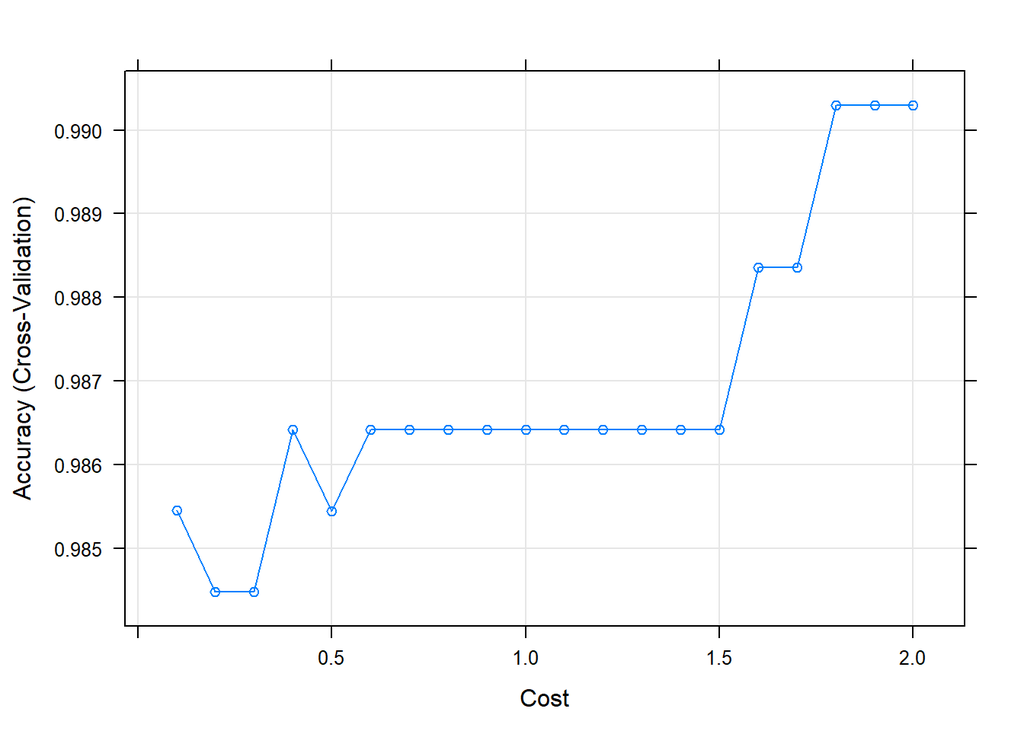

```r
plot(model_tune)
```

```r
model_tune$bestTune
```

|  | C |
| --- | --- |
| 18 | 1.8 |

```r
confusionMatrix(predicted.classes_tune, test$class, positive = "1")
```

```
## Confusion Matrix and Statistics
##
##           Reference
## Prediction   0   1
##          0 151   6
##          1   1 184
##
##                Accuracy : 0.9795
##                  95% CI : (0.9583, 0.9917)
##     No Information Rate : 0.5556
##     P-Value [Acc > NIR] : <2e-16
##
##                   Kappa : 0.9587
##
##  Mcnemar's Test P-Value : 0.1306
##
##             Sensitivity : 0.9684
##             Specificity : 0.9934
##          Pos Pred Value : 0.9946
##          Neg Pred Value : 0.9618
##              Prevalence : 0.5556
##          Detection Rate : 0.5380
##    Detection Prevalence : 0.5409
##       Balanced Accuracy : 0.9809
##
##        'Positive' Class : 1
##
```

SVM Linear Kernel (C = 1.8) Accuracy : 0.9795 Sensitivity : 0.9684 Specificity : 0.9934

## Support Vector Machine - Radial Kernel (C=0.5)

```r
set.seed(123)
model_svmRadial <- train(class~., data = train, method = "svmRadial",
trControl = trainControl("cv", number = 10),
preProcess=(c("scale","center")),
tuneLength = 10
)
model_svmRadial$bestTune
```

|  | sigma | C |
| --- | --- | --- |
| 2 | 0.4006328 | 0.5 |

```r
predicted.classes_svmRadial <- model_svmRadial %>% predict(test)
confusionMatrix(predicted.classes_svmRadial, test$class, positive = "1")
```

```
## Confusion Matrix and Statistics
##
##           Reference
## Prediction   0   1
##          0 152   0
##          1   0 190
##
##                Accuracy : 1
##                  95% CI : (0.9893, 1)
##     No Information Rate : 0.5556
##     P-Value [Acc > NIR] : < 2.2e-16
##
##                   Kappa : 1
##
##  Mcnemar's Test P-Value : NA
##
##             Sensitivity : 1.0000
##             Specificity : 1.0000
##          Pos Pred Value : 1.0000
##          Neg Pred Value : 1.0000
##              Prevalence : 0.5556
##          Detection Rate : 0.5556
##    Detection Prevalence : 0.5556
##       Balanced Accuracy : 1.0000
##
##        'Positive' Class : 1
##
```

SVM Radial Kernel (C = 0.5) Accuracy : 1 Sensitivity : 1.0000 Specificity : 1.0000

## SVM with Polynomial Kernel

```r
set.seed(123)
model_svmPoly <- train(class~., data = train, method = "svmPoly",
trControl = trainControl("cv", number = 10),
preProcess=(c("scale","center")),
tuneLength = 4
)
model_svmPoly$bestTune
```

|  | degree | scale | C |
| --- | --- | --- | --- |
| 29 | 2 | 1 | 0.25 |

```r
predicted.classes_svmPoly <- model_svmPoly %>% predict(test)
confusionMatrix(predicted.classes_svmPoly, test$class, positive = "1")
```

```
## Confusion Matrix and Statistics
##
##           Reference
## Prediction   0   1
##          0 152   0
##          1   0 190
##
##                Accuracy : 1
##                  95% CI : (0.9893, 1)
##     No Information Rate : 0.5556
##     P-Value [Acc > NIR] : < 2.2e-16
##
##                   Kappa : 1
##
##  Mcnemar's Test P-Value : NA
##
##             Sensitivity : 1.0000
##             Specificity : 1.0000
##          Pos Pred Value : 1.0000
##          Neg Pred Value : 1.0000
##              Prevalence : 0.5556
##          Detection Rate : 0.5556
##    Detection Prevalence : 0.5556
##       Balanced Accuracy : 1.0000
##
##        'Positive' Class : 1
##
```

SVM with Polynomial Kernel (C = 0.25) Accuracy : 1 Sensitivity : 1.0000 Specificity : 1.0000

# Neural Net

```r
#Re-Read the data
#Dependent variable should be numerical value in NeuralNet
data = read.csv('banknote.csv')
head(data)
```

|  | variance | skewness | curtosis | entropy | class |
| --- | --- | --- | --- | --- | --- |
| 1 | 3.62160 | 8.6661 | -2.8073 | -0.44699 | 1 |
| 2 | 4.54590 | 8.1674 | -2.4586 | -1.46210 | 1 |
| 3 | 3.86600 | -2.6383 | 1.9242 | 0.10645 | 1 |
| 4 | 3.45660 | 9.5228 | -4.0112 | -3.59440 | 1 |
| 5 | 0.32924 | -4.4552 | 4.5718 | -0.98880 | 1 |
| 6 | 4.36840 | 9.6718 | -3.9606 | -3.16250 | 1 |

## Data Partition

```r
set.seed(123)
training.sample = data$class %>% createDataPartition(p=0.75, list = FALSE)
train <- data[training.sample, ]
test <- data[-training.sample,]
```

## NN,SSE, 0 Hidden

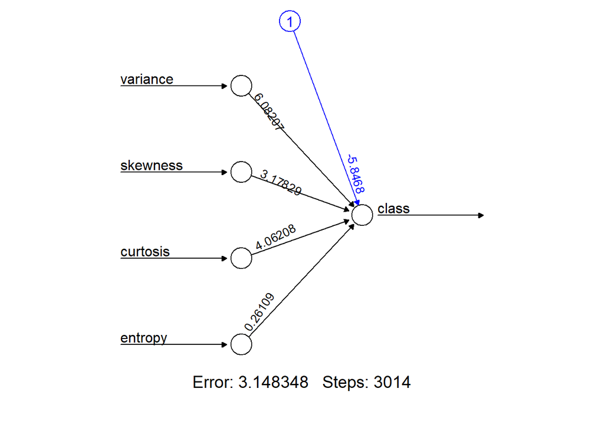

```r
#NeuralNet with "SSE" --> Sum of Square Error.
#No Hidden Layer
set.seed(123)
model_sse = neuralnet(class~., data = train, hidden = 0, err.fct = "sse", linear.output=F)
plot(model_sse, rep = "best")
```

```r
summary(model_sse)
```

```
##                     Length Class      Mode
## call                   6   -none-     call
## response            1029   -none-     numeric
## covariate           4116   -none-     numeric
## model.list             2   -none-     list
## err.fct                1   -none-     function
## act.fct                1   -none-     function
## linear.output          1   -none-     logical
## data                   5   data.frame list
## exclude                0   -none-     NULL
## net.result             1   -none-     list
## weights                1   -none-     list
## generalized.weights    1   -none-     list
## startweights           1   -none-     list
## result.matrix          8   -none-     numeric
```

```r
probabilities_sse = predict(model_sse, test)
predicted.classes_sse = ifelse(probabilities_sse > 0.5, 1, 0)
confusionMatrix(factor(predicted.classes_sse), factor(test$class), positive = "1")
```

```
## Confusion Matrix and Statistics
##
##           Reference
## Prediction   0   1
##          0 160   1
##          1   1 181
##
##                Accuracy : 0.9942
##                  95% CI : (0.9791, 0.9993)
##     No Information Rate : 0.5306
##     P-Value [Acc > NIR] : <2e-16
##
##                   Kappa : 0.9883
##
##  Mcnemar's Test P-Value : 1
##
##             Sensitivity : 0.9945
##             Specificity : 0.9938
##          Pos Pred Value : 0.9945
##          Neg Pred Value : 0.9938
##              Prevalence : 0.5306
##          Detection Rate : 0.5277
##    Detection Prevalence : 0.5306
##       Balanced Accuracy : 0.9941
##
##        'Positive' Class : 1
##
```

NN,SSE, 0 Hidden Accuracy : 0.9942 Sensitivity : 0.9945  
Specificity : 0.9938

# NN, CE, 0 Hidden

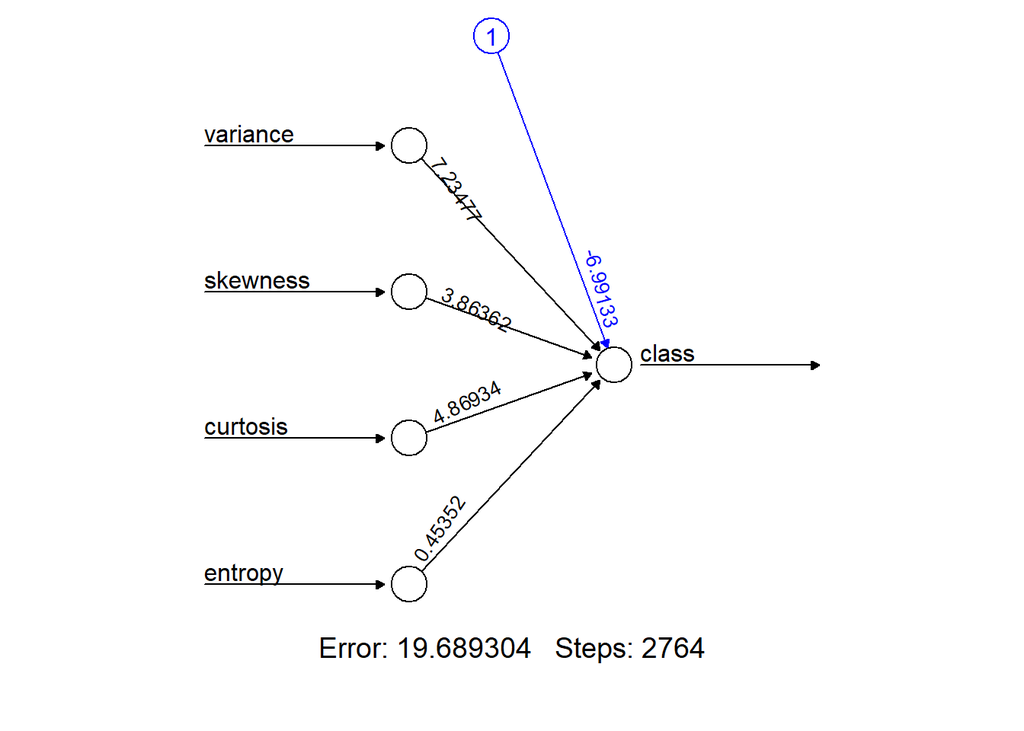

```r
# ce : Cross Entropy --> Good loss function for classification ==> Minimizes the distance between two(prdicted, actual) prob distributions.
set.seed(123)
model_ce = neuralnet(class~., data = train, hidden = 0, err.fct = "ce", linear.output=F)
plot(model_ce, rep = "best")
```

```r
probabilities_ce = predict(model_ce, test)
predicted.classes_ce = ifelse(probabilities_ce > 0.5, 1, 0)
confusionMatrix(factor(predicted.classes_ce), factor(test$class), positive = "1")
```

```
## Confusion Matrix and Statistics
##
##           Reference
## Prediction   0   1
##          0 160   3
##          1   1 179
##
##                Accuracy : 0.9883
##                  95% CI : (0.9704, 0.9968)
##     No Information Rate : 0.5306
##     P-Value [Acc > NIR] : <2e-16
##
##                   Kappa : 0.9766
##
##  Mcnemar's Test P-Value : 0.6171
##
##             Sensitivity : 0.9835
##             Specificity : 0.9938
##          Pos Pred Value : 0.9944
##          Neg Pred Value : 0.9816
##              Prevalence : 0.5306
##          Detection Rate : 0.5219
##    Detection Prevalence : 0.5248
##       Balanced Accuracy : 0.9887
##
##        'Positive' Class : 1
##
```

NN, CE, 0 Hidden Accuracy : 0.9883 Sensitivity : 0.9835  
Specificity : 0.9938

## Generalized Linear Model

```r
set.seed(123)
model_glm = glm(class~., family = binomial, data = train)
model_glm
```

```
##
## Call:  glm(formula = class ~ ., family = binomial, data = train)
##
## Coefficients:
## (Intercept)     variance     skewness     curtosis      entropy
##     -7.0385       7.2886       3.8913       4.9051       0.4592
##
## Degrees of Freedom: 1028 Total (i.e. Null);  1024 Residual
## Null Deviance:       1410
## Residual Deviance: 39.38     AIC: 49.38
```

```r
probabilities_glm = model_glm %>% predict(test, type = "response")
predicted.classes_glm = ifelse(probabilities_glm > 0.5, 1, 0)
confusionMatrix(factor(predicted.classes_glm), factor(test$class), positive = "1")
```

```
## Confusion Matrix and Statistics
##
##           Reference
## Prediction   0   1
##          0 160   3
##          1   1 179
##
##                Accuracy : 0.9883
##                  95% CI : (0.9704, 0.9968)
##     No Information Rate : 0.5306
##     P-Value [Acc > NIR] : <2e-16
##
##                   Kappa : 0.9766
##
##  Mcnemar's Test P-Value : 0.6171
##
##             Sensitivity : 0.9835
##             Specificity : 0.9938
##          Pos Pred Value : 0.9944
##          Neg Pred Value : 0.9816
##              Prevalence : 0.5306
##          Detection Rate : 0.5219
##    Detection Prevalence : 0.5248
##       Balanced Accuracy : 0.9887
##
##        'Positive' Class : 1
##
```

Accuracy : 0.9883 Sensitivity : 0.9835  
Specificity : 0.9938 Same as “ce” method